# Avaliação dos Programas de Pós-graduação Engenharia Biomédica, Engenharia de Sistemas Eletrônicos e de Automação, Engenharia Elétrica P7 e Engenharia Elétrica P8 e dos Currículos dos Professores e Pes

Quantidade de eventos por professor:

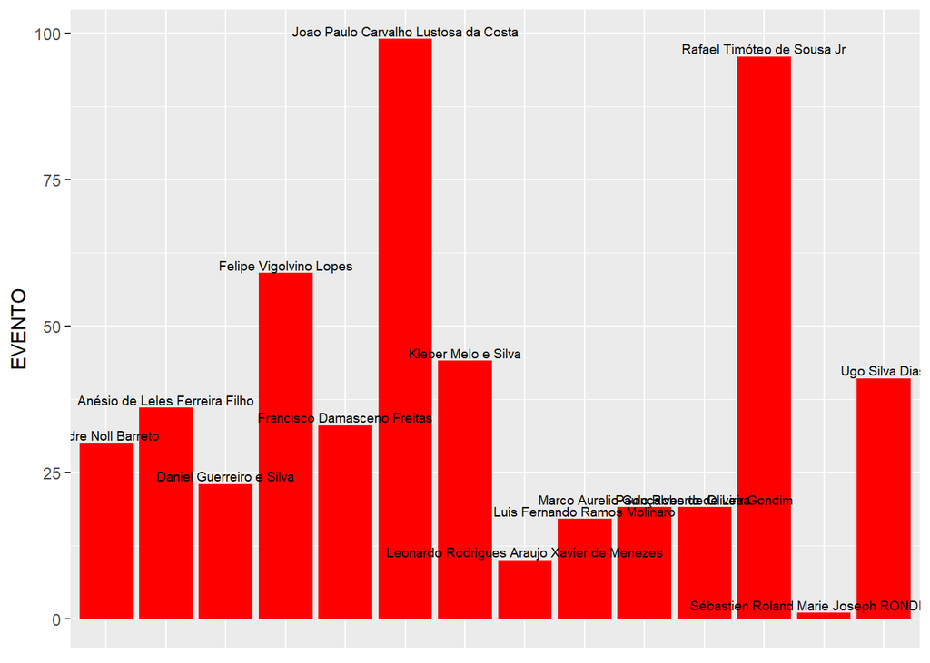

```r
unb.prof.ele_p7.df %>%
group_by(nome) %>%
filter(!is.na(EVENTO))%>%
ggplot(aes(x = nome, y = EVENTO)) +
geom_bar(position = "stack",stat = "identity", fill = "red")+
geom_text(aes(label=nome), vjust=-0.3, size=2.5)+
theme(axis.title.x=element_blank(),
        axis.text.x=element_blank(),
        axis.ticks.x=element_blank())
```

Quantidade de periódicos por professor:

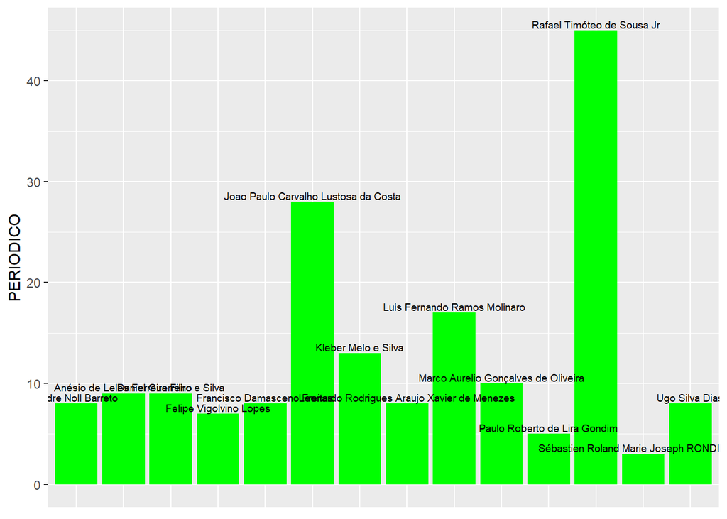

```r
unb.prof.ele_p7.df %>%
group_by(nome) %>%
filter(!is.na(PERIODICO))%>%
ggplot(aes(x = nome, y = PERIODICO)) +
geom_bar(position = "stack",stat = "identity", fill = "green")+
geom_text(aes(label=nome), vjust=-0.3, size=2.5)+
theme(axis.title.x=element_blank(),
        axis.text.x=element_blank(),
        axis.ticks.x=element_blank())
```

Quantidade de livros por professor:

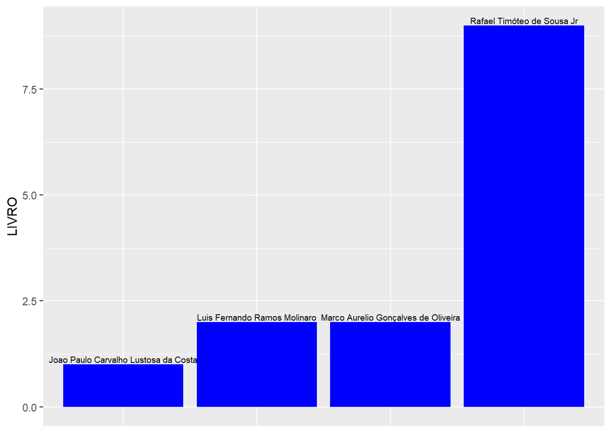

```r
unb.prof.ele_p7.df %>%
group_by(nome) %>%
filter(!is.na(LIVRO))%>%
ggplot(aes(x = nome, y = LIVRO)) +
geom_bar(position = "stack",stat = "identity", fill = "blue")+
geom_text(aes(label=nome), vjust=-0.3, size=2.5)+
theme(axis.title.x=element_blank(),
        axis.text.x=element_blank(),
        axis.ticks.x=element_blank())
```

Quantidade de texto em jornais por professor:

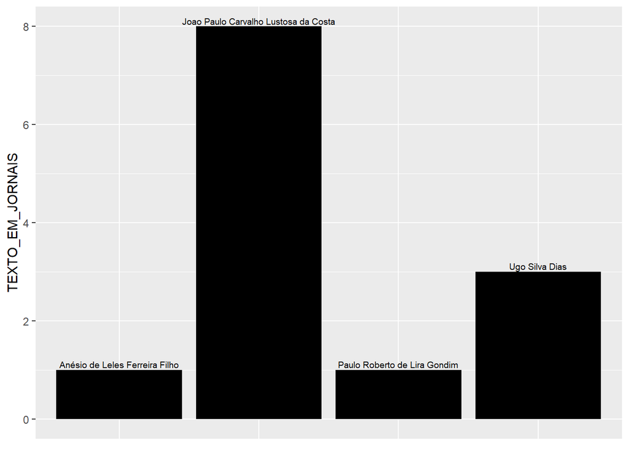

```r
unb.prof.ele_p7.df %>%
group_by(nome) %>%
filter(!is.na(TEXTO_EM_JORNAIS))%>%
ggplot(aes(x = nome, y = TEXTO_EM_JORNAIS)) +
geom_bar(position = "stack",stat = "identity", fill = "black")+
geom_text(aes(label=nome), vjust=-0.3, size=2.5)+
theme(axis.title.x=element_blank(),
        axis.text.x=element_blank(),
        axis.ticks.x=element_blank())
```

Relações entre professores:

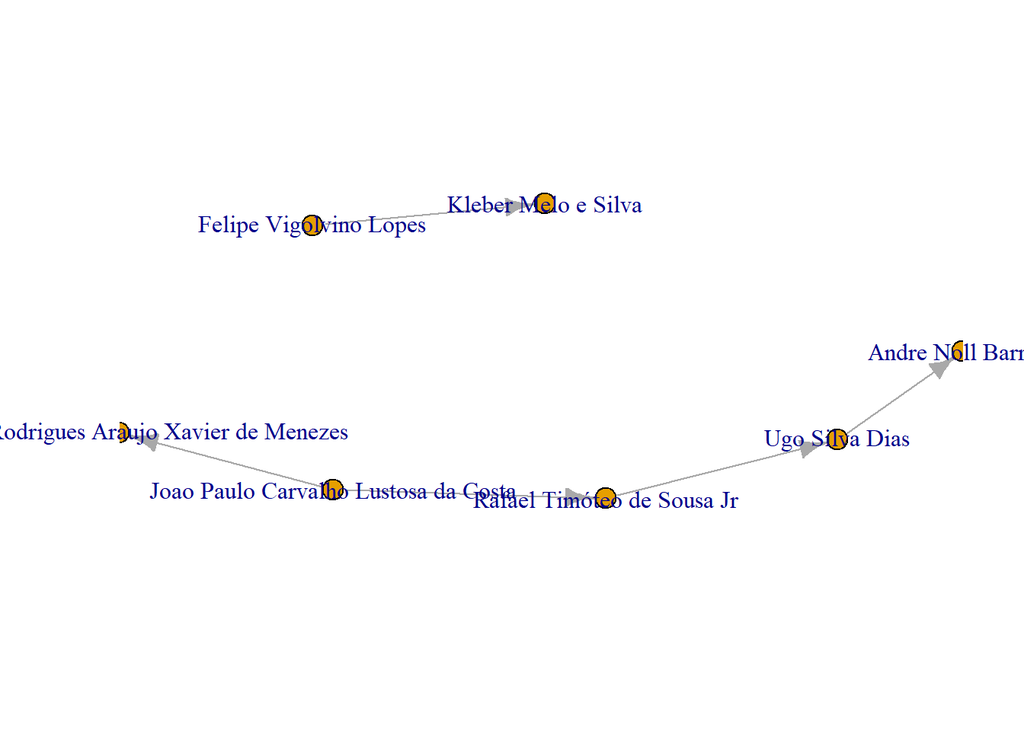

```r
list <- c(rbind(unb.graph.ele_p7$links$source,unb.graph.ele_p7$links$target))
idx <- match(list, unb.graph.ele_p7$nodes$id)
names <- unb.graph.ele_p7$nodes$properties$name
graph_names <- names[idx]
g <-graph(graph_names, directed=TRUE)
plot(g, layout = layout_(g, nicely()),
     edge.width = 1,
     edge.arrow.width = 1,
     vertex.size = 5,
     edge.arrow.size = 1,
     vertex.size2 = 3,
     vertex.label.cex = 1,
     asp = 0.35,
     margin = -0.1)
```

Nuvem de palavras baseadas no resumo do currículo dos professores:

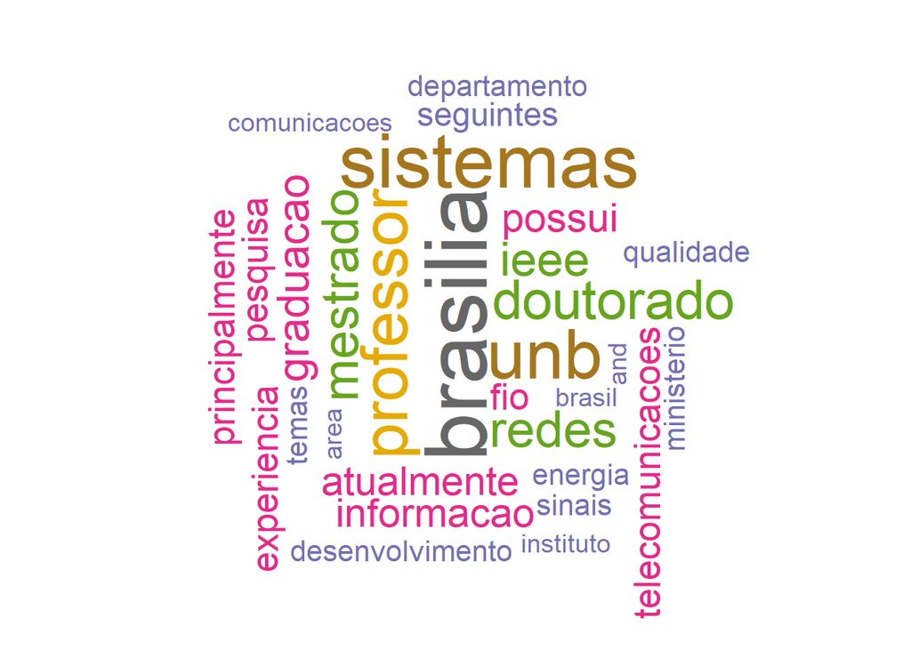

```r
unb.prof.ele_p7.df$resumo_cv <- iconv(unb.prof.ele_p7.df$resumo_cv,from="UTF-8", to = "ASCII//TRANSLIT")
df_wc <- data.frame(doc_id = unb.prof.ele_p7.df$idLattes, text = unb.prof.ele_p7.df$resumo_cv, stringsAsFactors = FALSE )
docs <- Corpus(DataframeSource(df_wc))
docs <- tm_map(docs, content_transformer(tolower))
docs <- tm_map(docs, removeNumbers)
docs <- tm_map(docs, removeWords, stopwords("pt"))
docs <- tm_map(docs, removeWords, c("universidade", "federal","eletrica","posgraduacao","engenheiro","engenharia"))
docs <- tm_map(docs, removePunctuation)
docs <- tm_map(docs, stripWhitespace)
dtm <- TermDocumentMatrix(docs)
m <- as.matrix(dtm)
v <- sort(rowSums(m),decreasing=TRUE)
d <- data.frame(word = names(v),freq=v)
set.seed(1234)
wordcloud(words =(d$word), freq = d$freq, min.freq = 3,
          max.words=30,scale = c(4, 0.2), random.order=FALSE, rot.per=0.35,
          colors=brewer.pal(8, "Dark2"))
```

Nuvem de palavras baseadas no título das orientações:

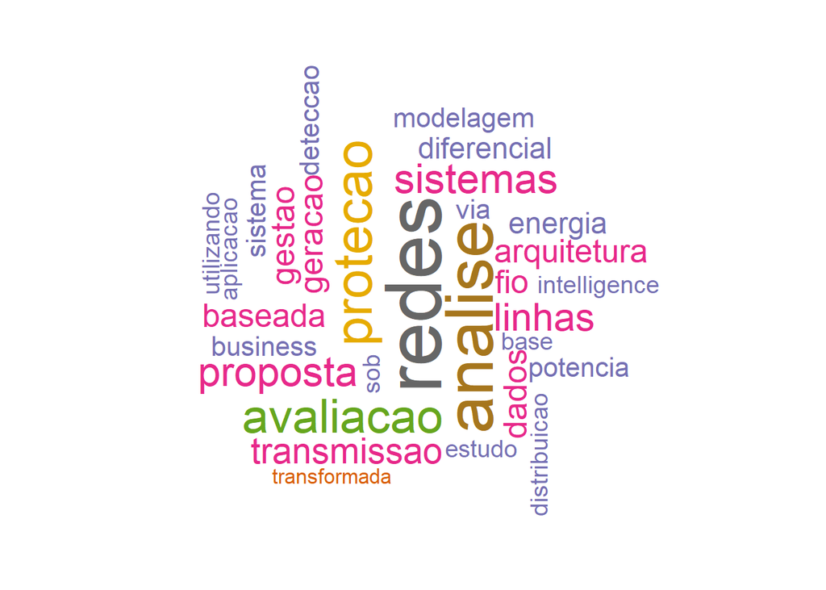

```r
unb.adv.ele_p7.df$titulo <- iconv(unb.adv.ele_p7.df$titulo,from="UTF-8", to = "ASCII//TRANSLIT")
df_wc <- data.frame(doc_id = unb.adv.ele_p7.df$idLattes1, text = unb.adv.ele_p7.df$titulo, stringsAsFactors = FALSE )
docs <- Corpus(DataframeSource(df_wc))
docs <- tm_map(docs, content_transformer(tolower))
docs <- tm_map(docs, removeNumbers)
docs <- tm_map(docs, removeWords, stopwords("pt"))
docs <- tm_map(docs, removeWords, stopwords("english"))
docs <- tm_map(docs, removeWords, c("universidade", "federal","eletrica","posgraduacao","engenheiro","engenharia"))
docs <- tm_map(docs, removePunctuation)
docs <- tm_map(docs, stripWhitespace)
dtm <- TermDocumentMatrix(docs)
m <- as.matrix(dtm)
v <- sort(rowSums(m),decreasing=TRUE)
d <- data.frame(word = names(v),freq=v)
set.seed(1234)
wordcloud(words =(d$word), freq = d$freq, min.freq = 3,
          max.words=30,scale = c(4, 0.2), random.order=FALSE, rot.per=0.35,
          colors=brewer.pal(8, "Dark2"))
```

# IX - Implatação

No caso deste trabalho, a implantação foi realizada por meio da implementação dos scripts apresentados no decorrer do documento.

# X - Conclusão

Ao final deste trabalho, podemos chegar a conclusão que com a metodologia CRISP-DM foi possível realizar uma análise de dados a partir de vários arquivos **JSON**, assim, foi possível perceber como funciona - pelo menos de maneira simplória - a vida de cientista de dados, como se deve preparar os dados, como se deve buscar informações úteis, analisar determinadas informações, plotar gráficos para um efeito mais visual, ver a dificuldade que falta de padronização causa, ainda mais quando se tem os mais diversos arquivos para analisar das mais diversas fontes.

O trabalho usou como base o arquivo disponibilizado pelo professor, no qual continha as explicações de todas as fases do CRISP-DM, seguindo o modelo passado pelo professor, tentou-se ir descorrendo sobre o script em R que se vinha fazendo e correlacionando com alguma fase do CRISP-DM, mas tal divisão não pode ser considerada totalmente fidedigna, haja visto que muitas vezes há mistura de fases e não apenas fases totalmente isoladas, sem influência de outras, procurou-se explicar de maneira simples como cada etapa se encaixava cada fase.

Por fim, podemos chegar a alguns resultados valorosos, mas nem tudo são flores, algumas dificuldades vieram em decorrência da falta de uniformidade, porém podemos aprender bastante com este trabalho e nos interar de como começar a fazer análise de dados.